# Estimating Power in Linear and Generalized Linear Mixed Models: An open introduction and tutorial in R

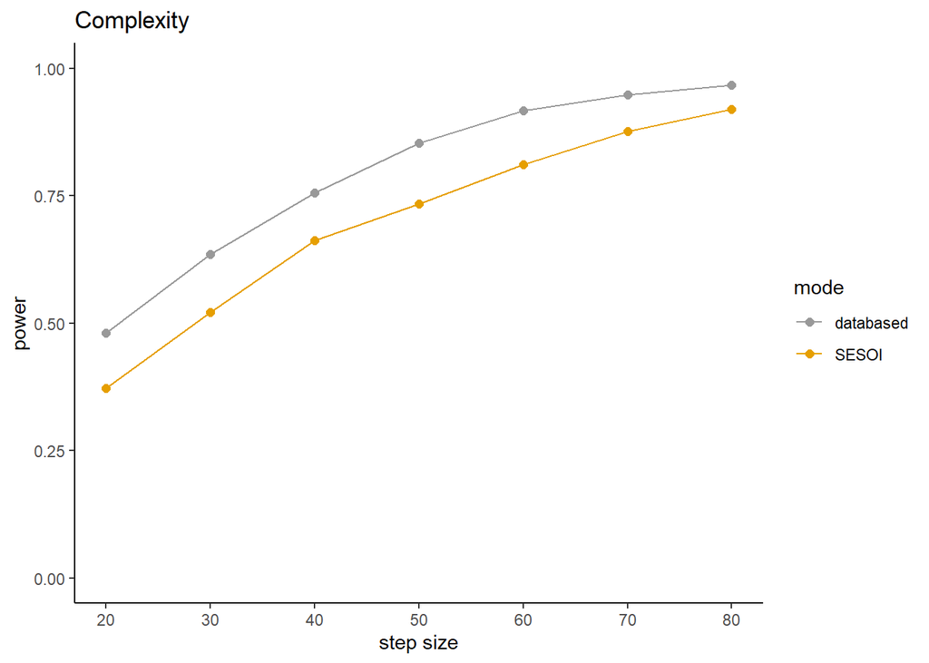

```r
complexity_plot
```

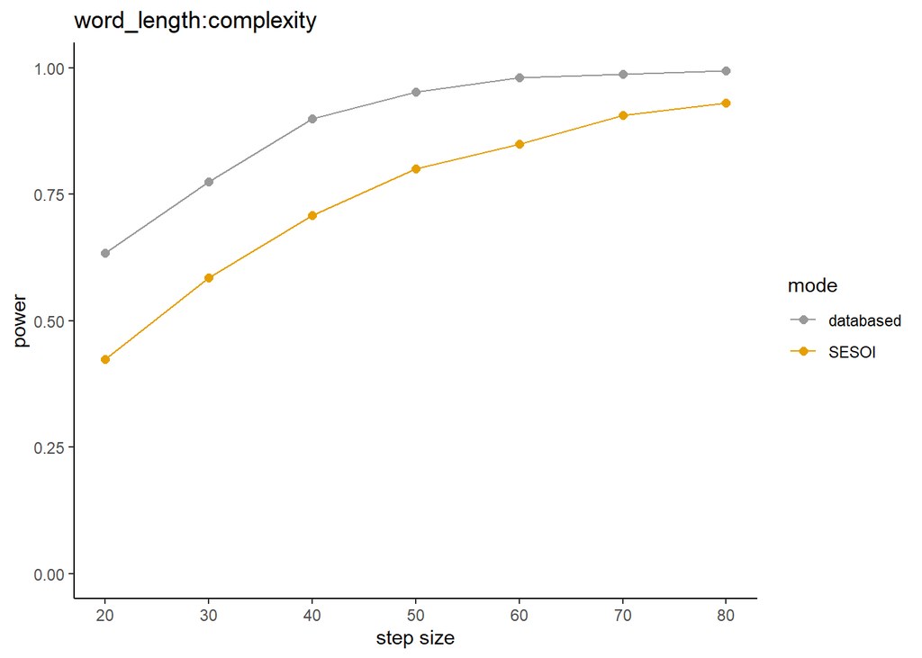

```r
interaction_plot
```

## Scenario 2: Simulating different units (random variables)

```r
fixed_effects_2 <- c("word_length", "complexity")
simvar_2 <- "sentence"
steps_2 <- c(100, 120, 140, 160, 180)
# ------------------------------------------ #
SESOI_2 <- c(3.66, 0.75, -0.065, 0.09)
# ------------------------------------------ #
# RUN SIMULATION
power_sentences <- mixedpower(model = FLPmodel,
                              data = YanData,
                              fixed_effects = fixed_effects_2,
                              simvar = simvar_2,
                              steps = steps_2,
                              SESOI = SESOI_2,
                              critical_value = 2,
                              n_sim = 1000,
                              databased = T)
```

*Plot and interpret results*

```r
#saveRDS(power_sentences,"power_sentences.rds")
scenario2_1 <- read_rds("power_sentences.rds")
datatable(scenario2_1)
```

|  | 100 | 120 | 140 | 160 | 180 | mode | effect |
| --- | --- | --- | --- | --- | --- | --- | --- |
| word_length | 1 | 1 | 1 | 1 | 1 | databased | word_length |
| complexity | 0.761 | 0.841 | 0.87 | 0.927 | 0.948 | databased | complexity |
| word_length:complexity | 0.89 | 0.931 | 0.954 | 0.981 | 0.985 | databased | word_length:complexity |
| word_length1 | 1 | 1 | 1 | 1 | 1 | SESOI | word_length |
| complexity1 | 0.651 | 0.725 | 0.768 | 0.827 | 0.844 | SESOI | complexity |
| word_length:complexity1 | 0.673 | 0.784 | 0.824 | 0.872 | 0.891 | SESOI | word_length:complexity |

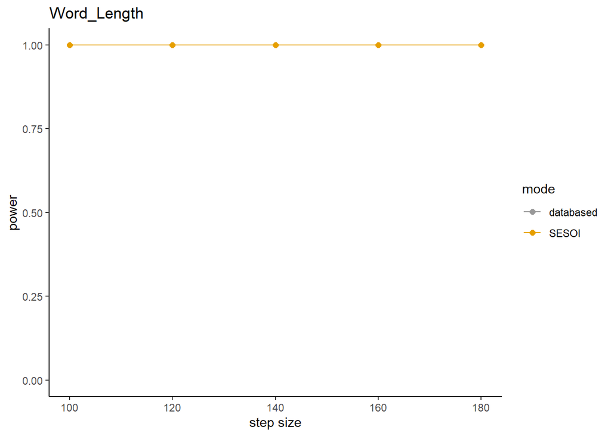

```r
# ------------------------------------------ #
#converting wide to long data
long_scenario2_1 <- scenario2_1 |>
  tidyr::pivot_longer(
    cols = c(
      paste(seq(100,180,20))
    ),
    names_to  = "sentences",
    values_to = "power"
  ) |>
  mutate(
    sentences = as.numeric(sentences)
  )

# ------------------------------------------ #
# Word_length data
scenario2.1_worldlength <- long_scenario2_1 |>
  filter(
    effect == "word_length"
  )

# ------------------------------------------ #
# Complexity data
scenario2.1_complexity <- long_scenario2_1 |>
  filter(
    effect == "complexity"
  )

# ------------------------------------------ #
# interaction data
scenario2.1_interaction <- long_scenario2_1 |>
  filter(
    effect == "word_length:complexity"
  )

# ------------------------------------------ #
# Word_length plot
word_plot2_1 <- ggplot(scenario2.1_worldlength,
                    aes(x = sentences,
                        y = power,
                        color = mode,
                        group = mode)) +
  geom_point(size = 2) +
  geom_line(size = 0.5) +
  ylim(0,1) +
  labs(title = "Word_Length",
       x = "step size",
       y = "power",) +
  scale_color_manual(values = cbPalette) +
  scale_x_continuous(limits = c(100,180),
                     breaks = seq(100,180,20)) +
  theme(legend.position = "right") +
  theme_classic()

# ------------------------------------------ #
# complexity plot
complexity_plot2_1 <- ggplot(scenario2.1_complexity,
                    aes(x = sentences,
                        y = power,
                        color = mode,
                        group = mode)) +
  geom_point(size = 2) +
  geom_line(size = 0.5) +
  ylim(0,1) +
  labs(title = "Complexity",
       x = "step size",
       y = "power") +
  scale_color_manual(values = cbPalette) +
  scale_x_continuous(limits = c(100,180),
                     breaks = seq(100,180,20)) +
  theme(legend.position = "right") +
  theme_classic()

# ------------------------------------------ #
# word_length:complexity plot
interaction_plot2_1 <- ggplot(scenario2.1_interaction,
                    aes(x = sentences,
                        y = power,
                        color = mode,
                        group = mode)) +
  geom_point(size = 2) +
  geom_line(size = 0.5) +
  ylim(0,1) +
  labs(title = "word_length:complexity",
       x = "step size",
       y = "power") +
  scale_color_manual(values = cbPalette) +
  scale_x_continuous(limits = c(100,180),
                     breaks = seq(100,180,20)) +
  theme(legend.position = "right") +
  theme_classic()

word_plot2_1
```

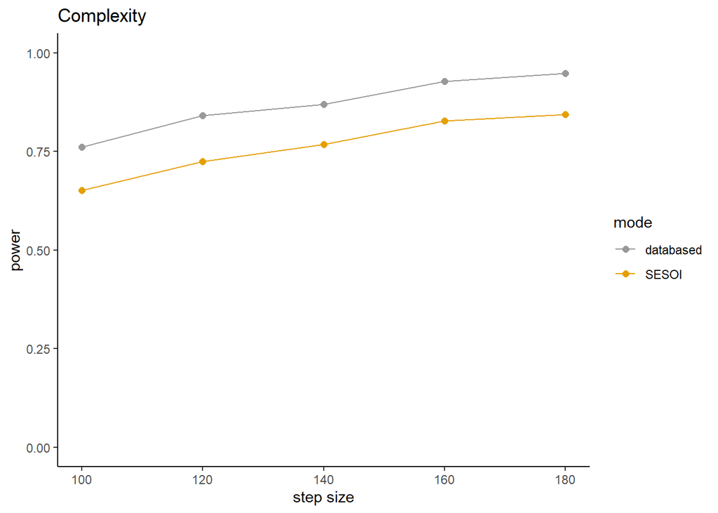

```r
complexity_plot2_1
```

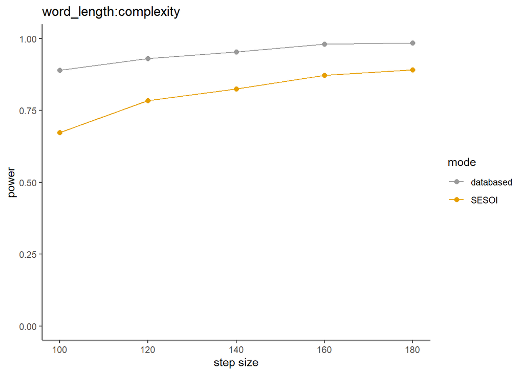

```r
interaction_plot2_1
```

*Varying the levels multiple random variables simultaneously*

So far, we only varied the levels of one random variable while we kept the other one constant. However, being able to vary both simultaneously would be desirable as it allows to estimate power for different combinations of levels.

```r
# ------------------------------------------ #
# SPECIFY R2 PARAMETERS
R2var <- "subject"
R2level <- 30

# ------------------------------------------ #
# RUN SIMULATION
R2power <- R2power(model = FLPmodel,
                   data = YanData,
                   fixed_effects = fixed_effects_2,
                   simvar = simvar_2,
                   steps = steps_2,
                   R2var = R2var,
                   R2level = R2level,
                   critical_value = 2,
                   SESOI = SESOI_2,
                   n_sim = 1000,
                   databased = T)
```

```r
# ------------------------------------------ #
# SPECIFY R2 PARAMETERS
R2var <- "subject"
R2level_48 <- 48

# ------------------------------------------ #
# RUN SIMULATION
R2power_48 <- R2power(model = FLPmodel,
                   data = YanData,
                   fixed_effects = fixed_effects_2,
                   simvar = simvar_2,
                   steps = steps_2,
                   R2var = R2var,
                   R2level = R2level_48,
                   critical_value = 2,
                   SESOI = SESOI_2,
                   n_sim = 1000,
                   databased = T)
```

```r
# ------------------------------------------ #
# SPECIFY R2 PARAMETERS
R2var <- "subject"
R2level_60 <- 60

# ------------------------------------------ #
# RUN SIMULATION
R2power_60 <- R2power(model = FLPmodel,
                   data = YanData,
                   fixed_effects = fixed_effects_2,
                   simvar = simvar_2,
                   steps = steps_2,
                   R2var = R2var,
                   R2level = R2level_60,
                   critical_value = 2,
                   SESOI = SESOI_2,
                   n_sim = 1000,
                   databased = T)
```

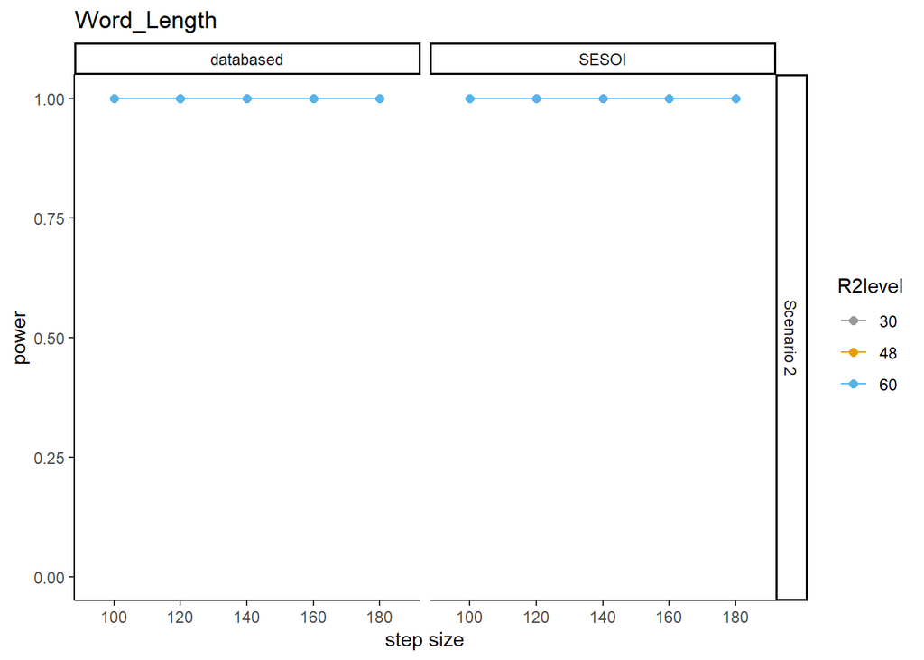

```r
scenario2_30_data <- readRDS("R2power_sentences_bysubject30.rds")
scenario2_30_data$subject <- 30
scenario2_48_data <- readRDS("R2power_sentences_bysubject48.rds")
scenario2_48_data$subject <- 48
scenario2_60_data <- readRDS("R2power_sentences_bysubject60.rds")
scenario2_60_data$subject <- 60
# ------------------------------------------ #
#converting wide to long data
wide_scenario2 <- dplyr::bind_rows(scenario2_30_data,
                      scenario2_48_data,
                      scenario2_60_data)
long_scenario2 <- wide_scenario2 |>
  tidyr::pivot_longer(
    cols = c(
      paste(seq(100,180,20))
    ),
    names_to  = "sentences",
    values_to = "power"
  )

# ------------------------------------------ #
# Word_length data
scenario2_worldlength <- long_scenario2 |>
  filter(
    effect == "word_length"
  ) |>
  mutate(
    subject = factor(subject)
  )

# ------------------------------------------ #
# Complexity data
scenario2_complexity <- long_scenario2 |>
  filter(
    effect == "complexity"
  ) |>
  mutate(
    subject = factor(subject),
    sentences = as.numeric(sentences)
  ) |>
  arrange(
    sentences,
    subject
  )

# ------------------------------------------ #
# interaction data
scenario2_interaction <- long_scenario2 |>
  filter(
    effect == "word_length:complexity"
  ) |>
  mutate(
    subject = factor(subject)
  )

# ------------------------------------------ #
# Word_length plot
word_plot <- ggplot(scenario2_worldlength,
                    aes(x = sentences,
                        y = power,
                        color = subject,
                        group = subject)) +
  facet_grid("Scenario 2"~ mode) +
  geom_point(size = 2) +
  geom_line(size = 0.5) +
  ylim(0,1) +
  labs(title = "Word_Length",
       x = "step size",
       y = "power",
       color = "R2level") +
  scale_color_manual(values = cbPalette) +
  theme(legend.position = "right") +
  theme_classic()

# ------------------------------------------ #
# complexity plot
complexity_plot <- ggplot(scenario2_complexity,
                    aes(x = sentences,
                        y = power,
                        color = subject,
                        group = subject)) +
  facet_grid("Scenario 2" ~ mode) +
  geom_point(size = 2) +
  geom_line(size = 0.5) +
  ylim(0,1) +
  labs(title = "Complexity",
       x = "step size",
       y = "power",
       color = "R2level") +
  scale_color_manual(values = cbPalette) +
  theme(legend.position = "right") +
  theme_classic()

# ------------------------------------------ #
# word_length:complexity plot
interaction_plot <- ggplot(scenario2_interaction,
                    aes(x = sentences,
                        y = power,
                        color = subject,
                        group = subject)) +
  facet_grid("Scenario 2" ~ mode) +
  geom_point(size = 2) +
  geom_line(size = 0.5) +
  ylim(0,1) +
  labs(title = "word_length:complexity",
       x = "step size",
       y = "power",
       color = "R2level") +
  scale_color_manual(values = cbPalette) +
  theme(legend.position = "right") +
  theme_classic()

word_plot
```

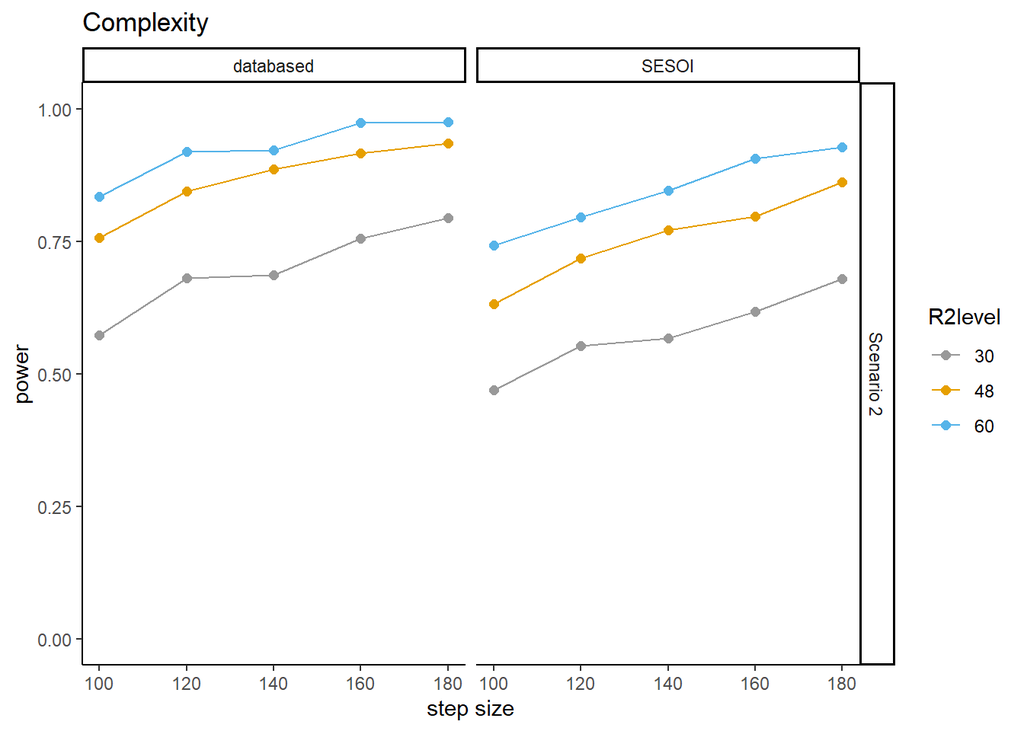

```r
complexity_plot
```

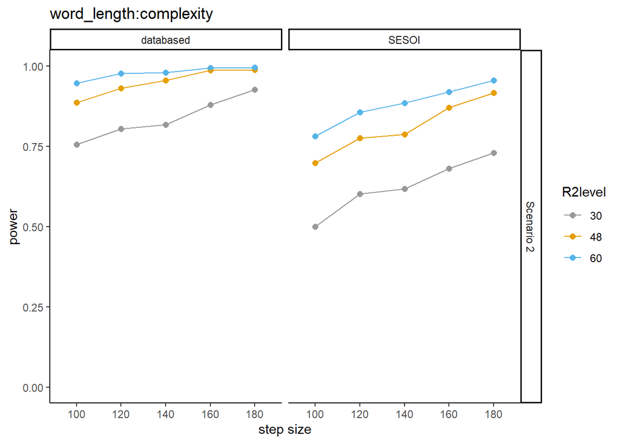

```r
interaction_plot
```

## Scenario 3: Having strong and detailed a priori assumptions

Simulation-based power analyses for (generalized) linear mixed models typically require a fitted model to inform the simulation. To fit a model, however, we need appropriate data that inform the model parameters. The simulations in Scenario 1 and 2 always made use of already existing data - but what if appropriate data is not available from previous research?

It is possible to build data and model from scratch to bypass the lack of appropriate existing data.

```r
# ------------------------------------------ #
# formula for artificial model
formula <- Correct ~ NativeLanguage * Frequency + (1 | Subject) + (1 | Word)

# ------------------------------------------ #
# Generalized linear mixed model
lexdec$CenteredFrequency <- scale(lexdec$Frequency, scale = F)
modelY <- glmer(Correct ~ NativeLanguage * CenteredFrequency +
                  (1 | Subject) +
                  (1 | Word),
                family = "binomial",
                data = lexdec)

summary(modelY)
```

```
Generalized linear mixed model fit by maximum likelihood (Laplace
  Approximation) [glmerMod]
 Family: binomial  ( logit )
Formula: Correct ~ NativeLanguage * CenteredFrequency + (1 | Subject) +
    (1 | Word)
   Data: lexdec

     AIC      BIC   logLik deviance df.resid
   497.1    529.6   -242.6    485.1     1653

Scaled residuals:
    Min      1Q  Median      3Q     Max
-1.0664 -0.1801 -0.1237 -0.0882  8.3312

Random effects:
 Groups  Name        Variance Std.Dev.
 Word    (Intercept) 1.0404   1.0200
 Subject (Intercept) 0.6578   0.8111
Number of obs: 1659, groups:  Word, 79; Subject, 21

Fixed effects:
                                      Estimate Std. Error z value Pr(>|z|)
(Intercept)                            -4.3076     0.4098 -10.512   <2e-16 ***
NativeLanguageOther                     0.3414     0.4926   0.693   0.4882
CenteredFrequency                      -0.3965     0.1887  -2.101   0.0357 *
NativeLanguageOther:CenteredFrequency  -0.3119     0.2175  -1.434   0.1516
---
Signif. codes:  0 '***' 0.001 '**' 0.01 '*' 0.05 '.' 0.1 ' ' 1

Correlation of Fixed Effects:
            (Intr) NtvLnO CntrdF
NtvLnggOthr -0.532
CntrdFrqncy  0.214 -0.141
NtvLnggO:CF -0.123  0.321 -0.567
```

*Artificial data*

```r
# ------------------------------------------ #
#  create subject ID
subject_ID <- (1:20)

# ------------------------------------------ #
#  every subject should read 100 words
stimuli_ID <- (1:100)

# ------------------------------------------ #
# combine subject IDs and stimui IDs
artificial_data <- expand.grid(Subject = subject_ID, Word = stimuli_ID)

# ------------------------------------------ #
# generate native language
native_language <- c(rep(-0.5, 1000), rep(0.5, 1000))

# ------------------------------------------ #
artificial_data["NativeLanguage"] <- native_language

# ------------------------------------------ #
#  generate frequency ratings
frequency_ratings <- rnorm(100, mean = 5, sd = 1) # draw 100 frequency rating (one for every word)

artificial_data["Frequency"] <- rep(frequency_ratings, 20) # multiply by 20 (for every subject)
artificial_data$CenteredFrequency <- scale(artificial_data$Frequency, scale = F)
```

*Building a model from scratch*

To create the desired generalized linear model (GLMM), we will make use of the **makeGlmer** function. Later, we will focus on the second question which requires a linear mixed model (LMM). All following steps regarding the power analysis are the same for LMMs and GLMMs - being able to fit a GLMM vs. LMM from scratch therefore is the only difference in this process.

Since we already specified the beta coefficients and random effect variances earlier, we can simply hand all information to the *makeGlmer()* function. Note how we specified “binomial” as the model’s family.

*Create Glmer*

```r
# ------------------------------------------ #
# SPECIFY BETA COEFFICIENTS FOR FIXED EFFECTS
fixed_effects <-  c(-4.3, 0.35, -0.4, -0.32)
# ------------------------------------------ #
# SET RANDOM INTERCEPT VARIANCE
random_variance <- list(1.04, 0.65)
# ------------------------------------------ #
# create GLMM
artificial_glmer <- makeGlmer(formula = Correct~NativeLanguage*
                                CenteredFrequency +
                                (1 | Subject)+
                                (1 | Word),
                              family = "binomial",
                              fixef = fixed_effects,
                              VarCorr = random_variance,
                              data = artificial_data)

# lets have a look!
summary(artificial_glmer)
```

```
Generalized linear mixed model fit by maximum likelihood (Laplace
  Approximation) [glmerMod]
 Family: binomial  ( logit )
Formula: Correct ~ NativeLanguage * CenteredFrequency + (1 | Subject) +
    (1 | Word)
   Data: artificial_data

     AIC      BIC   logLik deviance df.resid
   932.6    966.2   -460.3    920.6     1994

Scaled residuals:
    Min      1Q  Median      3Q     Max
-0.7716 -0.3154 -0.2419 -0.1906  4.4741

Random effects:
 Groups  Name        Variance Std.Dev.
 Word    (Intercept) 1.04     1.0198
 Subject (Intercept) 0.65     0.8062
Number of obs: 2000, groups:  Word, 100; Subject, 20

Fixed effects:
                                 Estimate Std. Error z value Pr(>|z|)
(Intercept)                      -4.30000    0.22791 -18.867  < 2e-16 ***
NativeLanguage                    0.35000    0.27262   1.284   0.1992
CenteredFrequency                -0.40000    0.09955  -4.018 5.87e-05 ***
NativeLanguage:CenteredFrequency -0.32000    0.18312  -1.747   0.0806 .
---
Signif. codes:  0 '***' 0.001 '**' 0.01 '*' 0.05 '.' 0.1 ' ' 1

Correlation of Fixed Effects:
            (Intr) NtvLng CntrdF
NativeLangg -0.010
CntrdFrqncy  0.001 -0.001
NtvLngg:CnF -0.001  0.022 -0.045
```

**Create Lmer**

```r
#------------------------------------------ #
# formula for LMM
formula_glmer <- Speed ~ NativeLanguage * CenteredFrequency + (1 | Subject) + (1 | Word)

# ------------------------------------------ #
# SPECIFY BETA COEFFICIENTS FOR FIXED EFFECTS
fixed_effects <-  c(1.7, -0.25, 0.02, 0.03)

# ------------------------------------------ #
# SET RANDOM INTERCEPT VARIANCE
random_variance <- list(0.007, 0.05)

# ------------------------------------------ #
# SET RESIDUAL STANDARD DEVIATION
sigma <- 0.26

# ------------------------------------------ #
# CREATE LMER
artificial_lmer <- makeLmer(formula = Speed ~ NativeLanguage *
                              CenteredFrequency +
                              (1 | Subject) +
                              (1 | Word),
                           fixef = fixed_effects,
                           VarCorr = random_variance,
                           sigma = sigma,
                           data = artificial_data)

# lets have a look!
summary(artificial_lmer)
```

```
Linear mixed model fit by REML ['lmerMod']
Formula: Speed ~ NativeLanguage * CenteredFrequency + (1 | Subject) +
    (1 | Word)
   Data: artificial_data

REML criterion at convergence: 415.3

Scaled residuals:
    Min      1Q  Median      3Q     Max
-3.3858 -0.6503 -0.0146  0.6628  3.9743

Random effects:
 Groups   Name        Variance Std.Dev.
 Word     (Intercept) 0.0070   0.08367
 Subject  (Intercept) 0.0500   0.22361
 Residual             0.0676   0.26000
Number of obs: 2000, groups:  Word, 100; Subject, 20

Fixed effects:
                                  Estimate Std. Error t value
(Intercept)                       1.700000   0.051027  33.315
NativeLanguage                   -0.250000   0.020376 -12.269
CenteredFrequency                 0.020000   0.006884   2.905
NativeLanguage:CenteredFrequency  0.030000   0.012676   2.367

Correlation of Fixed Effects:
            (Intr) NtvLng CntrdF
NativeLangg 0.000
CntrdFrqncy 0.000  0.000
NtvLngg:CnF 0.000  0.000  0.000
```

*mixedpower*

```r
# ------------------------------------------ #
# INFORMATION ABOUT MODEL USED FOR SIMULATION

model <- artificial_glmer
data <- artificial_data
fixed_effects <- c("NativeLanguage", "CenteredFrequency")
simvar <- "Subject"

# ------------------------------------------ #
power_scenario3 <- mixedpower(model = model,
                    data = data,
                    fixed_effects = fixed_effects,
                    simvar = simvar ,
                    steps = c(20,60,100,140,180),
                    critical_value = 2,
                    n_sim = 1000,
                    SESOI = c(-4.3,  0.30 ,-0.34, -0.27))
```

*Plot and interpret results*

```r
#saveRDS(power_scenario3,"power_scenario3.rds")
scenario3 <- read_rds("power_scenario3.rds")
datatable(scenario3)
```

|  | 20 | 60 | 100 | 140 | 180 | mode | effect |
| --- | --- | --- | --- | --- | --- | --- | --- |
| NativeLanguage | 0.11 | 0.36 | 0.52 | 0.73 | 0.93 | databased | NativeLanguage |
| CenteredFrequency | 0.81 | 0.99 | 1 | 1 | 1 | databased | CenteredFrequency |
| NativeLanguage:CenteredFrequency | 0.2 | 0.62 | 0.87 | 0.92 | 0.98 | databased | NativeLanguage:CenteredFrequency |
| NativeLanguage1 | 0.11 | 0.34 | 0.46 | 0.71 | 0.79 | SESOI | NativeLanguage |
| CenteredFrequency1 | 0.69 | 0.98 | 1 | 1 | 1 | SESOI | CenteredFrequency |
| NativeLanguage:CenteredFrequency1 | 0.18 | 0.35 | 0.67 | 0.78 | 0.83 | SESOI | NativeLanguage:CenteredFrequency |

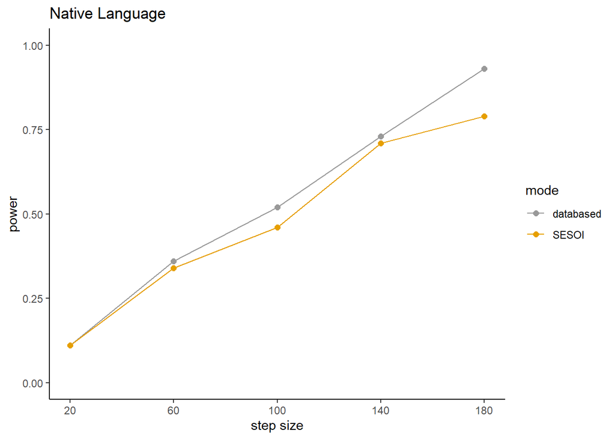

```r
# ------------------------------------------ #
#converting wide to long data
long_scenario3 <- scenario3 |>
  tidyr::pivot_longer(
    cols = c(
      paste(seq(20,180,40))
    ),
    names_to  = "subject",
    values_to = "power"
  ) |>
  mutate(
    subject = as.numeric(subject)
  )

# ------------------------------------------ #
# NativeLanguage data
scenario3_NativeLanguage <- long_scenario3 |>
  filter(
    effect == "NativeLanguage"
  )

# ------------------------------------------ #
# CenteredFrequency data
scenario3_CenteredFrequency <- long_scenario3 |>
  filter(
    effect == "CenteredFrequency"
  )

# ------------------------------------------ #
# interaction data
scenario3_interaction <- long_scenario3 |>
  filter(
    effect == "NativeLanguage:CenteredFrequency"
  )

# ------------------------------------------ #
# NativeLanguage plot
NativeLanguage_plot <- ggplot(scenario3_NativeLanguage,
                    aes(x = subject,
                        y = power,
                        color = mode,
                        group = mode)) +
  geom_point(size = 2) +
  geom_line(size = 0.5) +
  ylim(0,1) +
  labs(title = "Native Language",
       x = "step size",
       y = "power",) +
  scale_color_manual(values = cbPalette) +
  scale_x_continuous(limits = c(20,180),
                     breaks = seq(20,180,40)) +
  theme(legend.position = "right") +
  theme_classic()

# ------------------------------------------ #
# CenteredFrequency plot
Frequency_plot <- ggplot(scenario3_CenteredFrequency,
                    aes(x = subject,
                        y = power,
                        color = mode,
                        group = mode)) +
  geom_point(size = 2) +
  geom_line(size = 0.5) +
  ylim(0,1) +
  labs(title = "Frequency",
       x = "step size",
       y = "power") +
  scale_color_manual(values = cbPalette) +
  scale_x_continuous(limits = c(20,180),
                     breaks = seq(20,180,40)) +
  theme(legend.position = "right") +
  theme_classic()

# ------------------------------------------ #
# NativeLanguage:CenteredFrequency plot
Interaction_plot <- ggplot(scenario3_interaction,
                    aes(x = subject,
                        y = power,
                        color = mode,
                        group = mode)) +
  geom_point(size = 2) +
  geom_line(size = 0.5) +
  ylim(0,1) +
  labs(title = "Interaction",
       x = "step size",
       y = "power") +
  scale_color_manual(values = cbPalette) +
  scale_x_continuous(limits = c(20,180),
                     breaks = seq(20,180,40)) +
  theme(legend.position = "right") +
  theme_classic()

NativeLanguage_plot
```

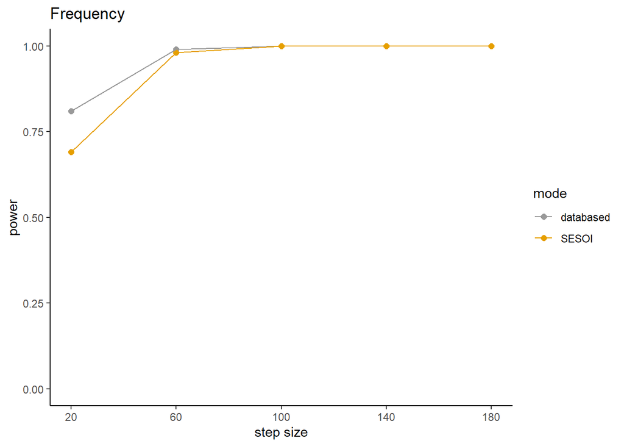

```r
Frequency_plot
```

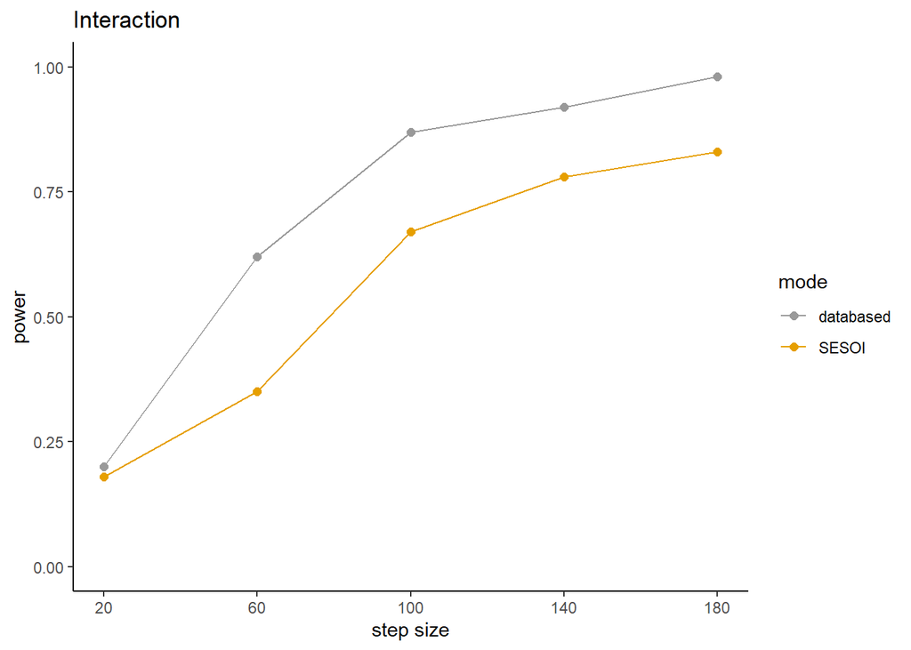

```r
Interaction_plot
```

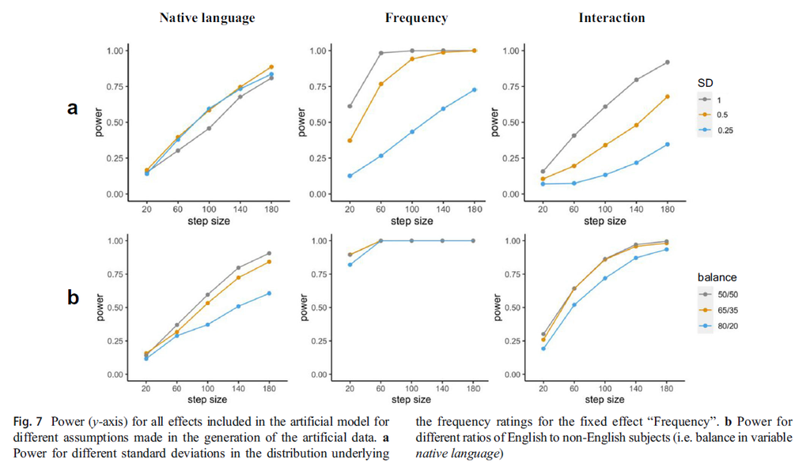